# Predicting Sleep Disorders Using Lifestyle and Health Factors

DA5030 Signature Project

Mayank Gandhi

Fall 2025

# 1 **PHASE 1 — Business Understanding**

#### 1.0.0.1 *PHASE 1 focuses on defining the problem, goals, and success criteria (business understanding)*

## 1.1 Problem Context

Sleep is fundamental to how people think, feel, and function day to day. Persistent problems such as insomnia and sleep apnea are linked to poor concentration, low mood, higher cardiovascular and metabolic risk, and reduced work performance. Yet many people with disturbed sleep are never formally diagnosed or are diagnosed late.

Simple, low-cost screening tools based on routine information (age, lifestyle, basic health measures) could help flag people who might be at higher risk of a sleep disorder. These tools are not meant to replace clinical assessment, but to support earlier awareness and encourage follow-up with a health professional.

## 1.2 Analytic Objective

The goal of this project is to build and compare machine learning models that predict an individual’s sleep disorder status from demographic, lifestyle, and health variables. The target variable, **Sleep.Disorder**, has three categories (“None”, “Insomnia”, “Sleep Apnea”), so this is a **multi-class classification** problem.

The main questions are:

- How accurately can sleep disorder status be predicted from variables such as age, sleep duration, stress level, physical activity, BMI category, blood pressure, and heart rate?
- Which variables appear most strongly associated with having a sleep disorder?
- Does an ensemble that combines several models outperform any single model on its own?

The analysis follows the **CRISP-DM** framework: business understanding, data understanding, data preparation, modeling, evaluation, and interpretation.

## 1.3 Data Source and Scope

The project uses the **Sleep Health and Lifestyle Dataset**, originally published on Kaggle and mirrored in a public GitHub repository to meet the requirement that data must be loaded from a web URL. Each row represents one person and includes demographic information, lifestyle habits, simple health measurements, and a recorded sleep disorder label.

- Original source: Kaggle – “Sleep Health and Lifestyle Dataset”
- Access here: CSV file hosted on GitHub
- Unit of analysis: individual person
- Target variable: **Sleep.Disorder** (None / Insomnia / Sleep.Apnea after cleaning)

## 1.4 Success Criteria

Model performance will be assessed using multi-class classification metrics, primarily **Accuracy** and **Kappa** on a held-out test set, supported by confusion matrices and per-class metrics (Recall, Precision, and F1-score). From a practical perspective, the model is considered useful if it:

- improves meaningfully on naive guessing,
- identifies individuals with insomnia or sleep apnea with reasonable sensitivity, and
- remains interpretable enough to explain which features are driving predictions.

# 2 **PHASE 2 — Data Understanding**

#### 2.0.0.1 *PHASE 2 focuses on exploring the raw data, checking quality, and understanding basic patterns*

## 2.1 Load Data

```r
suppressPackageStartupMessages({
  library(ggplot2)
  library(caret)
  library(corrplot)
  library(randomForest)
  library(e1071)   # SVM
  library(gbm)     # Boosting
  library(nnet)   # multinom
})


# Load data from public GitHub URL
data_gtb_url <- "https://raw.githubusercontent.com/mayankgandhi13/DA5030-Signature_Project/refs/heads/main/Sleep_health_and_lifestyle_dataset.csv"

sleep_raw <- read.csv(data_gtb_url,
                      stringsAsFactors = FALSE)

# Quick preview
head(sleep_raw)
```

```
##   Person.ID Gender Age           Occupation Sleep.Duration Quality.of.Sleep
## 1         1   Male  27    Software Engineer            6.1                6
## 2         2   Male  28               Doctor            6.2                6
## 3         3   Male  28               Doctor            6.2                6
## 4         4   Male  28 Sales Representative            5.9                4
## 5         5   Male  28 Sales Representative            5.9                4
## 6         6   Male  28    Software Engineer            5.9                4
##   Physical.Activity.Level Stress.Level BMI.Category Blood.Pressure Heart.Rate
## 1                      42            6   Overweight         126/83         77
## 2                      60            8       Normal         125/80         75
## 3                      60            8       Normal         125/80         75
## 4                      30            8        Obese         140/90         85
## 5                      30            8        Obese         140/90         85
## 6                      30            8        Obese         140/90         85
##   Daily.Steps Sleep.Disorder
## 1        4200           None
## 2       10000           None
## 3       10000           None
## 4        3000    Sleep Apnea
## 5        3000    Sleep Apnea
## 6        3000       Insomnia
```

```r
tail(sleep_raw)
```

```
##     Person.ID Gender Age Occupation Sleep.Duration Quality.of.Sleep
## 369       369 Female  59      Nurse            8.1                9
## 370       370 Female  59      Nurse            8.1                9
## 371       371 Female  59      Nurse            8.0                9
## 372       372 Female  59      Nurse            8.1                9
## 373       373 Female  59      Nurse            8.1                9
## 374       374 Female  59      Nurse            8.1                9
##     Physical.Activity.Level Stress.Level BMI.Category Blood.Pressure Heart.Rate
## 369                      75            3   Overweight         140/95         68
## 370                      75            3   Overweight         140/95         68
## 371                      75            3   Overweight         140/95         68
## 372                      75            3   Overweight         140/95         68
## 373                      75            3   Overweight         140/95         68
## 374                      75            3   Overweight         140/95         68
##     Daily.Steps Sleep.Disorder
## 369        7000    Sleep Apnea
## 370        7000    Sleep Apnea
## 371        7000    Sleep Apnea
## 372        7000    Sleep Apnea
## 373        7000    Sleep Apnea
## 374        7000    Sleep Apnea
```

```r
dim(sleep_raw)
```

```
## [1] 374  13
```

This chunk loads the required packages and imports the dataset directly from the GitHub URL so the notebook remains fully reproducible. The **head(), tail(),**and **dim()** outputs confirm that the file was read correctly and give a quick look at the dataset’s size and contents.

## 2.2 Structure and Variable Types

Here, I examine the overall structure of the dataset to understand how variables are currently encoded and to get a first sense of ranges and potential issues.

```r
str(sleep_raw)
```

```
## 'data.frame':    374 obs. of  13 variables:
##  $ Person.ID              : int  1 2 3 4 5 6 7 8 9 10 ...
##  $ Gender                 : chr  "Male" "Male" "Male" "Male" ...
##  $ Age                    : int  27 28 28 28 28 28 29 29 29 29 ...
##  $ Occupation             : chr  "Software Engineer" "Doctor" "Doctor" "Sales Representative" ...
##  $ Sleep.Duration         : num  6.1 6.2 6.2 5.9 5.9 5.9 6.3 7.8 7.8 7.8 ...
##  $ Quality.of.Sleep       : int  6 6 6 4 4 4 6 7 7 7 ...
##  $ Physical.Activity.Level: int  42 60 60 30 30 30 40 75 75 75 ...
##  $ Stress.Level           : int  6 8 8 8 8 8 7 6 6 6 ...
##  $ BMI.Category           : chr  "Overweight" "Normal" "Normal" "Obese" ...
##  $ Blood.Pressure         : chr  "126/83" "125/80" "125/80" "140/90" ...
##  $ Heart.Rate             : int  77 75 75 85 85 85 82 70 70 70 ...
##  $ Daily.Steps            : int  4200 10000 10000 3000 3000 3000 3500 8000 8000 8000 ...
##  $ Sleep.Disorder         : chr  "None" "None" "None" "Sleep Apnea" ...
```

```r
colnames(sleep_raw)
```

```
##  [1] "Person.ID"               "Gender"
##  [3] "Age"                     "Occupation"
##  [5] "Sleep.Duration"          "Quality.of.Sleep"
##  [7] "Physical.Activity.Level" "Stress.Level"
##  [9] "BMI.Category"            "Blood.Pressure"
## [11] "Heart.Rate"              "Daily.Steps"
## [13] "Sleep.Disorder"
```

```r
summary(sleep_raw)
```

```
##    Person.ID         Gender               Age         Occupation
##  Min.   :  1.00   Length:374         Min.   :27.00   Length:374
##  1st Qu.: 94.25   Class :character   1st Qu.:35.25   Class :character
##  Median :187.50   Mode  :character   Median :43.00   Mode  :character
##  Mean   :187.50                      Mean   :42.18
##  3rd Qu.:280.75                      3rd Qu.:50.00
##  Max.   :374.00                      Max.   :59.00
##  Sleep.Duration  Quality.of.Sleep Physical.Activity.Level  Stress.Level
##  Min.   :5.800   Min.   :4.000    Min.   :30.00           Min.   :3.000
##  1st Qu.:6.400   1st Qu.:6.000    1st Qu.:45.00           1st Qu.:4.000
##  Median :7.200   Median :7.000    Median :60.00           Median :5.000
##  Mean   :7.132   Mean   :7.313    Mean   :59.17           Mean   :5.385
##  3rd Qu.:7.800   3rd Qu.:8.000    3rd Qu.:75.00           3rd Qu.:7.000
##  Max.   :8.500   Max.   :9.000    Max.   :90.00           Max.   :8.000
##  BMI.Category       Blood.Pressure       Heart.Rate     Daily.Steps
##  Length:374         Length:374         Min.   :65.00   Min.   : 3000
##  Class :character   Class :character   1st Qu.:68.00   1st Qu.: 5600
##  Mode  :character   Mode  :character   Median :70.00   Median : 7000
##                                        Mean   :70.17   Mean   : 6817
##                                        3rd Qu.:72.00   3rd Qu.: 8000
##                                        Max.   :86.00   Max.   :10000
##  Sleep.Disorder
##  Length:374
##  Class :character
##  Mode  :character
##
##
##
```

## 2.3 Initial Data Quality Assessment

Next, I check for missing values and duplicate rows, as these directly affect data preparation and model robustness.

```r
# Missing values per column
colSums(is.na(sleep_raw))
```

```
##               Person.ID                  Gender                     Age
##                       0                       0                       0
##              Occupation          Sleep.Duration        Quality.of.Sleep
##                       0                       0                       0
## Physical.Activity.Level            Stress.Level            BMI.Category
##                       0                       0                       0
##          Blood.Pressure              Heart.Rate             Daily.Steps
##                       0                       0                       0
##          Sleep.Disorder
##                       0
```

```r
# Number of duplicated rows
sum(duplicated(sleep_raw))
```

```
## [1] 0
```

This output indicates where missing values occur (for example, in BMI if present) and whether there are any exact duplicate rows. These findings will drive the imputation and cleaning steps in Phase 3.

## 2.4 Target Variable Distribution

Understanding the distribution of the target variable `Sleep.Disorder` is crucial for model evaluation and for selecting appropriate metrics in later phases.

```r
table(sleep_raw$Sleep.Disorder)
```

```
##
##    Insomnia        None Sleep Apnea
##          77         219          78
```

```r
prop.table(table(sleep_raw$Sleep.Disorder))
```

```
##
##    Insomnia        None Sleep Apnea
##   0.2058824   0.5855615   0.2085561
```

Here I report the counts and proportions for each class (None, Insomnia, Sleep Apnea). If one class is much more common than the others, the dataset is imbalanced, and accuracy alone may be a misleading performance measure. This motivates the use of additional metrics such as Recall, F1-score, and confusion matrices in the evaluation phase.

## 2.5 Basic Exploratory Plots

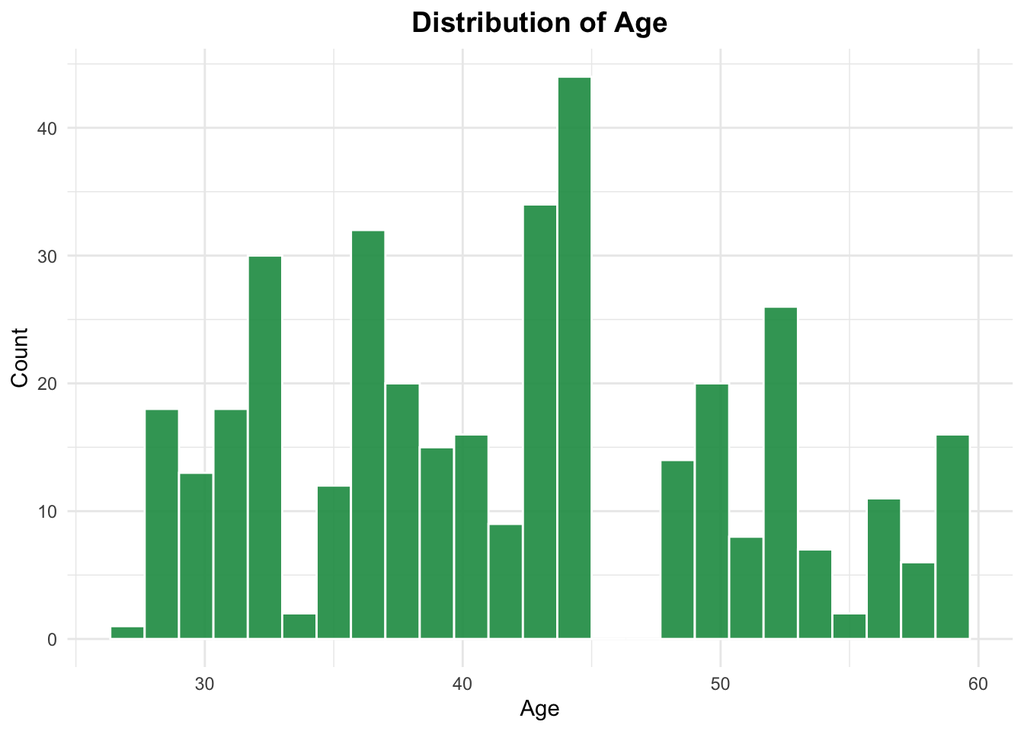

```r
# Histogram of Age
ggplot(sleep_raw, aes(x = Age)) +
  geom_histogram(
    bins = 25,
    fill = "#1a9850",
    color = "white",
    alpha = 0.9
  ) +
  labs(
    title = "Distribution of Age",
    x = "Age",
    y = "Count"
  ) +
  theme_minimal() +
  theme(
    plot.title = element_text(
      hjust = 0.5,
      face = "bold",
      size = 14
    )
  )
```

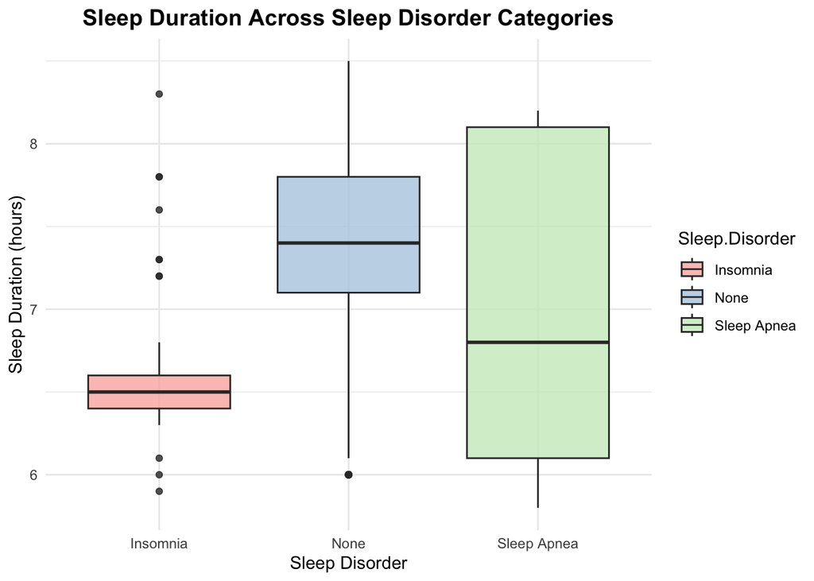

```r
# Boxplot of Sleep Duration by Sleep Disorder
ggplot(sleep_raw, aes(x = Sleep.Disorder, y = Sleep.Duration, fill = Sleep.Disorder)) +
  geom_boxplot(alpha = 0.8) +
  scale_fill_brewer(palette = "Pastel1") +
  labs(
    title = "Sleep Duration Across Sleep Disorder Categories",
    x = "Sleep Disorder",
    y = "Sleep Duration (hours)"
  ) +
  theme_minimal() +
  theme(
    plot.title = element_text(
      hjust = 0.5,
      face = "bold",
      size = 14
    )
  )
```

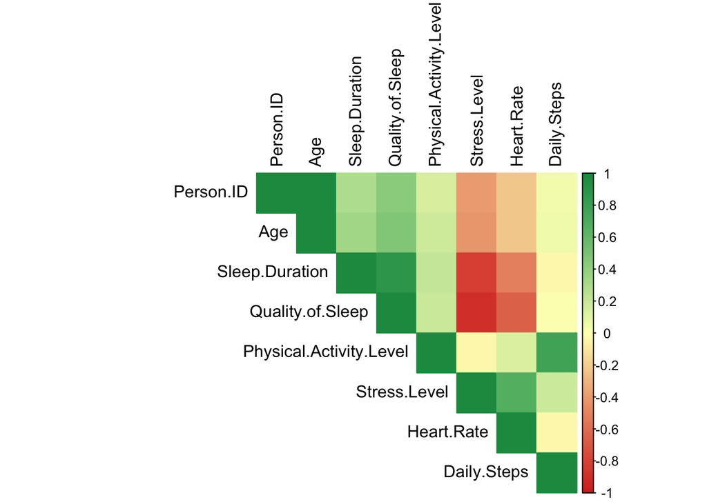

```r
# Correlation heatmap for numeric variables
num_vars <- sapply(sleep_raw, is.numeric)
corr_matrix <- cor(sleep_raw[, num_vars])

corrplot(
  corr_matrix,
  method = "color",
  type = "upper",
  tl.col = "black",
  tl.srt = 90,
  col = colorRampPalette(c("#d73027", "#ffffbf", "#1a9850"))(200)
)
```

These plots provide a quick visual check on how age and sleep duration are distributed, and whether individuals with insomnia or sleep apnea tend to have different sleep patterns than those without a diagnosed sleep disorder. More detailed EDA will follow in the Data Preparation phase.

## 2.6 Outlier Detection

```r
# Simple outlier check using IQR for Sleep.Duration
Q1 <- quantile(sleep_raw$Sleep.Duration, 0.25, na.rm = TRUE)
Q3 <- quantile(sleep_raw$Sleep.Duration, 0.75, na.rm = TRUE)
IQR_val <- Q3 - Q1

lower_bound <- Q1 - 1.5 * IQR_val
upper_bound <- Q3 + 1.5 * IQR_val

sum(sleep_raw$Sleep.Duration < lower_bound | sleep_raw$Sleep.Duration > upper_bound)
```

```
## [1] 0
```

I used the IQR rule to check for extreme outliers in Sleep Duration; very few (or no) observations fell outside the 1.5×IQR range, so no trimming was applied.

## 2.7 Categorical Association Analysis

```r
## 2.7 — Categorical Association Analysis (Chi-Square + Heatmap)

# Chi-square test: BMI Category vs Sleep Disorder
chisq.test(table(sleep_raw$BMI.Category, sleep_raw$Sleep.Disorder))
```

```
##
##  Pearson's Chi-squared test
##
## data:  table(sleep_raw$BMI.Category, sleep_raw$Sleep.Disorder)
## X-squared = 246.97, df = 6, p-value < 2.2e-16
```

```r
# Chi-square test: Gender vs Sleep Disorder
chisq.test(table(sleep_raw$Gender, sleep_raw$Sleep.Disorder))
```

```
##
##  Pearson's Chi-squared test
##
## data:  table(sleep_raw$Gender, sleep_raw$Sleep.Disorder)
## X-squared = 54.306, df = 2, p-value = 1.613e-12
```

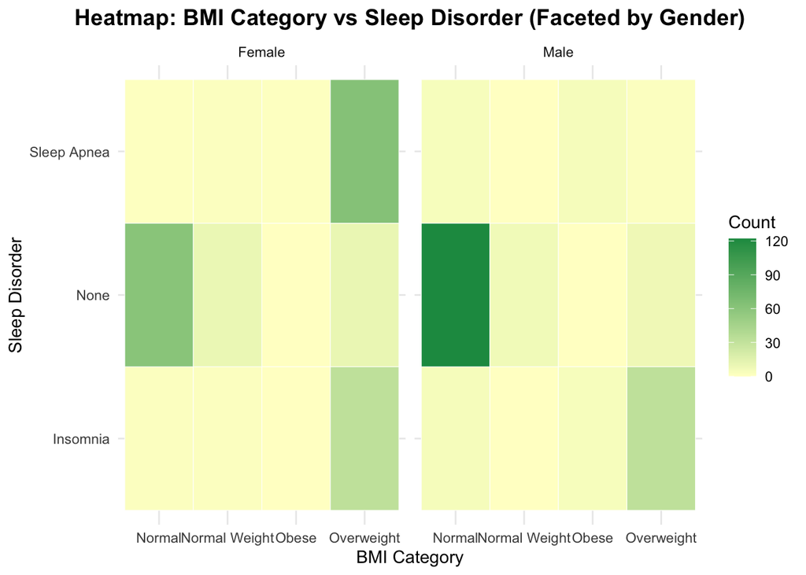

```r
# Heatmap: BMI Category vs Sleep Disorder, Faceted by Gender

bmi_gender_tab <- as.data.frame(table(
  Gender        = sleep_raw$Gender,
  BMI.Category  = sleep_raw$BMI.Category,
  Sleep.Disorder = sleep_raw$Sleep.Disorder
))

ggplot(bmi_gender_tab, aes(x = BMI.Category, y = Sleep.Disorder, fill = Freq)) +
  geom_tile(color = "white") +
  scale_fill_gradient(low = "#ffffcc", high = "#1a9850") +
  labs(
    title = "Heatmap: BMI Category vs Sleep Disorder (Faceted by Gender)",
    x     = "BMI Category",
    y     = "Sleep Disorder",
    fill  = "Count"
  ) +
  theme_minimal() +
  theme(
    plot.title = element_text(
      hjust = 0.5,
      face  = "bold",
      size  = 14
    )
  ) +
  facet_wrap(~ Gender)
```

The chi-square tests and the heatmap together help explain how categorical predictors relate to sleep disorder outcomes. **Both BMI Category and Gender showed strong statistical associations with sleep disorders, with BMI showing a particularly large effect (χ² = 246.97, p < 0.001) and Gender also significant (χ² = 54.31, p < 0.001).**

# 3 **PHASE 3 — Data Preparation**

#### 3.0.0.1 *PHASE 3 focuses on preparing data (cleaning, encoding, imputation, scaling, PCA diagnostics) before modeling*

## 3.1 Cleaning names

```r
sleep <- sleep_raw
names(sleep) <- make.names(names(sleep))

colnames(sleep)
```

```
##  [1] "Person.ID"               "Gender"
##  [3] "Age"                     "Occupation"
##  [5] "Sleep.Duration"          "Quality.of.Sleep"
##  [7] "Physical.Activity.Level" "Stress.Level"
##  [9] "BMI.Category"            "Blood.Pressure"
## [11] "Heart.Rate"              "Daily.Steps"
## [13] "Sleep.Disorder"
```

The column names are cleaned using **make.names()** to ensure they are valid R identifiers. Printing the updated names confirms that all variables were renamed consistently and safely for later modeling steps.

## 3.2 Convert Variables to Appropriate Types

The target **must** be a factor for classification. Several predictors should also be categorical.

```r
# Convert target variable to factor
sleep$Sleep.Disorder <- as.factor(sleep$Sleep.Disorder)

# Ensure safe factor level names for modeling (no spaces etc.)
sleep$Sleep.Disorder <- factor(make.names(as.character(sleep$Sleep.Disorder)))

# Identify potential categorical predictors
cat_vars <- c("Gender", "Occupation", "BMI.Category")

# Convert only if present in dataset
cat_vars <- cat_vars[cat_vars %in% names(sleep)]

for (v in cat_vars) {
  sleep[[v]] <- as.factor(sleep[[v]])
}

str(sleep)
```

```
## 'data.frame':    374 obs. of  13 variables:
##  $ Person.ID              : int  1 2 3 4 5 6 7 8 9 10 ...
##  $ Gender                 : Factor w/ 2 levels "Female","Male": 2 2 2 2 2 2 2 2 2 2 ...
##  $ Age                    : int  27 28 28 28 28 28 29 29 29 29 ...
##  $ Occupation             : Factor w/ 11 levels "Accountant","Doctor",..: 10 2 2 7 7 10 11 2 2 2 ...
##  $ Sleep.Duration         : num  6.1 6.2 6.2 5.9 5.9 5.9 6.3 7.8 7.8 7.8 ...
##  $ Quality.of.Sleep       : int  6 6 6 4 4 4 6 7 7 7 ...
##  $ Physical.Activity.Level: int  42 60 60 30 30 30 40 75 75 75 ...
##  $ Stress.Level           : int  6 8 8 8 8 8 7 6 6 6 ...
##  $ BMI.Category           : Factor w/ 4 levels "Normal","Normal Weight",..: 4 1 1 3 3 3 3 1 1 1 ...
##  $ Blood.Pressure         : chr  "126/83" "125/80" "125/80" "140/90" ...
##  $ Heart.Rate             : int  77 75 75 85 85 85 82 70 70 70 ...
##  $ Daily.Steps            : int  4200 10000 10000 3000 3000 3000 3500 8000 8000 8000 ...
##  $ Sleep.Disorder         : Factor w/ 3 levels "Insomnia","None",..: 2 2 2 3 3 1 1 2 2 2 ...
```

The target variable and key categorical predictors (Sleep.Disorder, Gender, Occupation, BMI.Category) are converted to factors so that the models correctly treat them as categorical rather than numeric variables.

## 3.3 Missing Value Assessment & Imputation

Before modeling, missing data must be addressed. Median imputation is robust for skewed numeric variables.

```r
# Check missing values again after type conversion

colSums(is.na(sleep))
```

```
##               Person.ID                  Gender                     Age
##                       0                       0                       0
##              Occupation          Sleep.Duration        Quality.of.Sleep
##                       0                       0                       0
## Physical.Activity.Level            Stress.Level            BMI.Category
##                       0                       0                       0
##          Blood.Pressure              Heart.Rate             Daily.Steps
##                       0                       0                       0
##          Sleep.Disorder
##                       0
```

```r
# Median imputation for BMI, only if missing

if ("BMI" %in% names(sleep)) {
  sleep$BMI[is.na(sleep$BMI)] <- median(sleep$BMI, na.rm = TRUE)
}

colSums(is.na(sleep))
```

```
##               Person.ID                  Gender                     Age
##                       0                       0                       0
##              Occupation          Sleep.Duration        Quality.of.Sleep
##                       0                       0                       0
## Physical.Activity.Level            Stress.Level            BMI.Category
##                       0                       0                       0
##          Blood.Pressure              Heart.Rate             Daily.Steps
##                       0                       0                       0
##          Sleep.Disorder
##                       0
```

## 3.4 Quick Visual Distribution Checks

This helps confirm features behave reasonably before modeling.

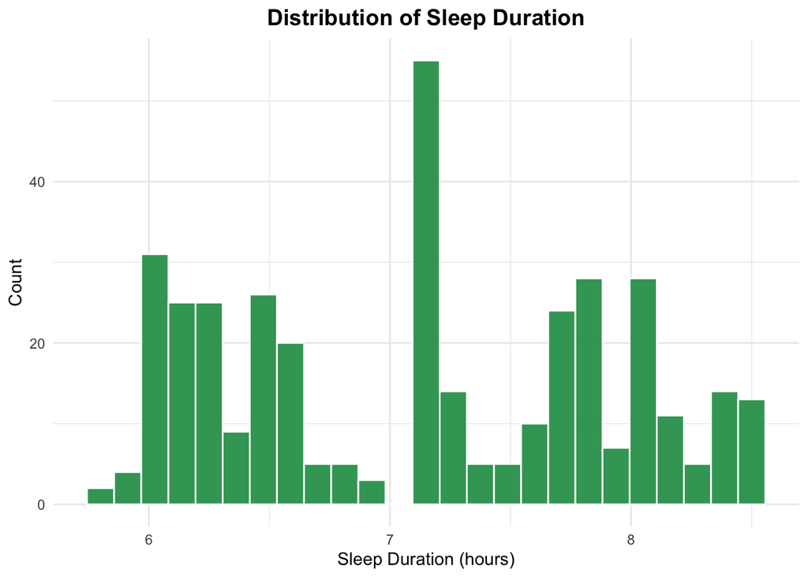

```r
# Histogram of Sleep Duration
ggplot(sleep, aes(x = Sleep.Duration)) +
  geom_histogram(
    bins  = 25,
    fill  = "#1a9850",
    color = "white",
    alpha = 0.9
  ) +
  labs(
    title = "Distribution of Sleep Duration",
    x     = "Sleep Duration (hours)",
    y     = "Count"
  ) +
  theme_minimal() +
  theme(
    plot.title = element_text(
      hjust = 0.5,
      face  = "bold",
      size  = 14
    )
  )
```

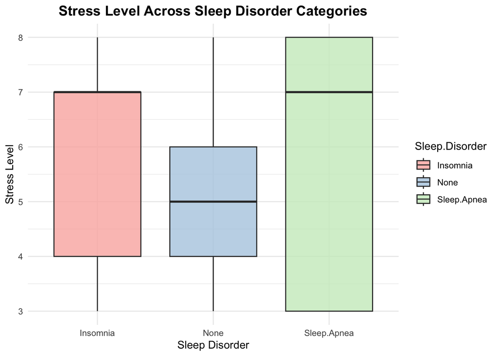

```r
# Boxplot of Stress Level by Sleep Disorder
ggplot(sleep, aes(x = Sleep.Disorder, y = Stress.Level, fill = Sleep.Disorder)) +
  geom_boxplot(alpha = 0.8) +
  scale_fill_brewer(palette = "Pastel1") +
  labs(
    title = "Stress Level Across Sleep Disorder Categories",
    x     = "Sleep Disorder",
    y     = "Stress Level"
  ) +
  theme_minimal() +
  theme(
    plot.title = element_text(
      hjust = 0.5,
      face  = "bold",
      size  = 14
    )
  )
```

These plots show how sleep duration is distributed in the sample and how stress levels vary across the three sleep disorder categories. They provide a quick check that the variables look reasonable and hint at potential differences between people with and without a diagnosed sleep disorder.

## 3.5 Principal Component Check

```r
# Select numeric features only
num_vars <- sapply(sleep, is.numeric)
sleep_num <- sleep[, num_vars]

# Standardize inside PCA
pca_fit <- prcomp(sleep_num, center = TRUE, scale. = TRUE)
summary(pca_fit)
```

```
## Importance of components:
##                           PC1    PC2    PC3     PC4     PC5    PC6     PC7
## Standard deviation     1.9571 1.3646 1.1736 0.78692 0.39687 0.2994 0.23789
## Proportion of Variance 0.4788 0.2328 0.1722 0.07741 0.01969 0.0112 0.00707
## Cumulative Proportion  0.4788 0.7116 0.8837 0.96112 0.98081 0.9920 0.99909
##                            PC8
## Standard deviation     0.08524
## Proportion of Variance 0.00091
## Cumulative Proportion  1.00000
```

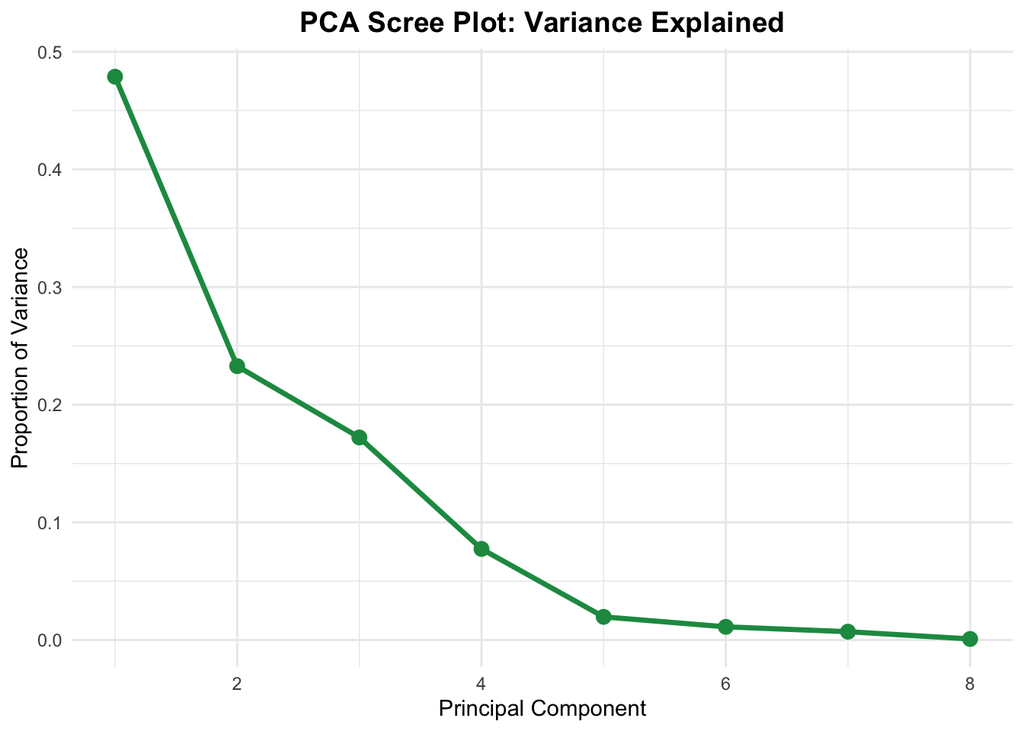

```r
# Scree plot (variance explained)
pca_var <- pca_fit$sdev^2
pca_var_exp <- pca_var / sum(pca_var)

# Scree plot
ggplot(
  data.frame(PC = 1:length(pca_var_exp), VarExp = pca_var_exp),
  aes(x = PC, y = VarExp)
) +
  geom_line(color = "#1a9850", linewidth = 1.2) +
  geom_point(color = "#1a9850", size = 3) +
  labs(
    title = "PCA Scree Plot: Variance Explained",
    x = "Principal Component",
    y = "Proportion of Variance"
  ) +
  theme_minimal() +
  theme(
    plot.title = element_text(
      hjust = 0.5,
      face = "bold",
      size = 14
    )
  )
```

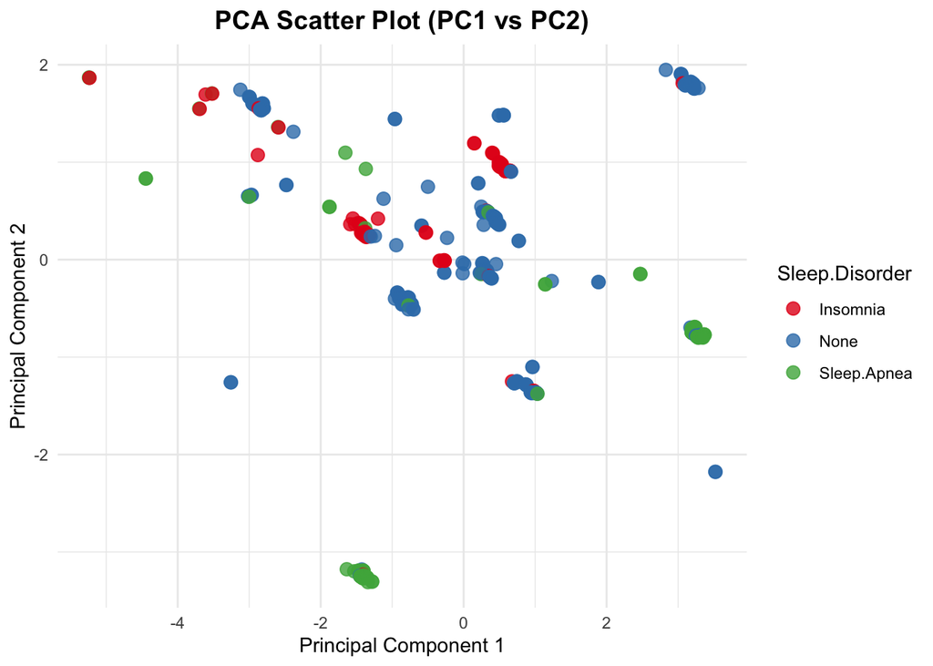

```r
# PCA scores for first two components
pca_scores <- data.frame(pca_fit$x[, 1:2])
pca_scores$Sleep.Disorder <- sleep$Sleep.Disorder

# Biplot-like visualization using PC1 & PC2
ggplot(pca_scores, aes(x = PC1, y = PC2, color = Sleep.Disorder)) +
  geom_point(alpha = 0.8, size = 3) +
  labs(
    title = "PCA Scatter Plot (PC1 vs PC2)",
    x = "Principal Component 1",
    y = "Principal Component 2"
  ) +
  scale_color_brewer(palette = "Set1") +
  theme_minimal() +
  theme(
    plot.title = element_text(
      hjust = 0.5,
      face = "bold",
      size = 14
    )
  )
```

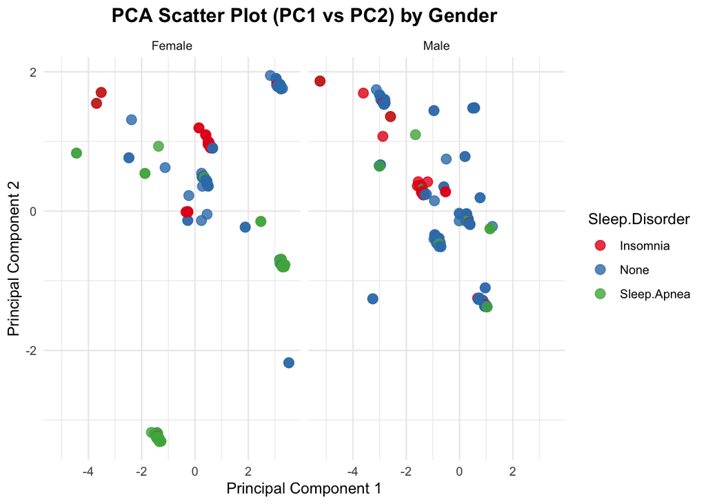

```r
# Add Gender to PCA scores
pca_scores$Gender <- sleep$Gender

# PCA scatter plot faceted by Gender
ggplot(pca_scores, aes(x = PC1, y = PC2, color = Sleep.Disorder)) +
  geom_point(alpha = 0.8, size = 3) +
  labs(
    title = "PCA Scatter Plot (PC1 vs PC2) by Gender",
    x     = "Principal Component 1",
    y     = "Principal Component 2"
  ) +
  scale_color_brewer(palette = "Set1") +
  theme_minimal() +
  theme(
    plot.title = element_text(
      hjust = 0.5,
      face  = "bold",
      size  = 14
    )
  ) +
  facet_wrap(~ Gender)
```

**-No additional feature engineering was performed, because the existing variables (sleep duration, stress, BMI category, blood pressure, heart rate) are already interpretable and clinically meaningful; creating synthetic combinations on a <400-row dataset would mostly add noise and overfitting risk.**

## 3.6 Stratified Train–Test Split

Maintains class balance between training and testing sets — important for multi-class classification.

```r
set.seed(123)

train_index <- createDataPartition(
  sleep$Sleep.Disorder,
  p = 0.7,
  list = FALSE
)

train_data <- sleep[train_index, ]
test_data  <- sleep[-train_index, ]

# Neat dimensions printout
cat("Train rows:", nrow(train_data), " | Columns:", ncol(train_data), "\n")
```

```
## Train rows: 263  | Columns: 13
```

```r
cat("Test  rows:", nrow(test_data),  " | Columns:", ncol(test_data),  "\n\n")
```

```
## Test  rows: 111  | Columns: 13
```

```r
# Check class proportions in train and test
cat("Training class proportions:\n")
```

```
## Training class proportions:
```

```r
print(prop.table(table(train_data$Sleep.Disorder)))
```

```
##
##    Insomnia        None Sleep.Apnea
##   0.2053232   0.5855513   0.2091255
```

```r
cat("\nTest class proportions:\n")
```

```
##
## Test class proportions:
```

```r
print(prop.table(table(test_data$Sleep.Disorder)))
```

```
##
##    Insomnia        None Sleep.Apnea
##   0.2072072   0.5855856   0.2072072
```

The dataset is split into a **70/30 train–test split** using stratified sampling on Sleep.Disorder. Stratification preserves the class proportions in both subsets, which is important for multi-class classification and prevents the models from being trained on an imbalanced sample. The printed dimensions and class proportions confirm that the split was performed correctly.

## 3.7 Preprocessing Strategy for Modeling

Different models have different preprocessing requirements, so the data is prepared in a way that satisfies all of them. Logistic Regression and SVM rely on distance-based calculations, so their numeric predictors need to be **normalized/standardized**. This is handled automatically using `preProcess = c("center", "scale")` inside the `caret::train()` call, which standardizes all numeric features to mean 0 and standard deviation 1 **within each resampling fold**.

Random Forest and GBM do not require scaling because they are tree-based methods and can work directly with both numeric and categorical predictors. All preprocessing is done inside the cross-validation loop rather than on the full dataset, which avoids data leakage and ensures a fair evaluation of model performance.

# 4 **PHASE 4 — Modeling**

#### 4.0.0.1 *PHASE 4 focuses on constructing and tuning multiple models using cross-validation*

## 4.1 Cross-validation

```r
set.seed(123)

ctrl_cv <- trainControl(
  method = "cv",
  number = 10,                  # 10-fold CV required by instructor
  savePredictions = "final",
  classProbs = TRUE             # needed for probabilities later
)
```

This `trainControl()` setup creates 10-fold cross-validation, which means the training data is repeatedly split into internal **training and validation subsets** for every model. Each model is tuned and evaluated on these validation folds before we ever look at the 30% hold-out test set, so the rubric requirement for separate training and validation during model construction is satisfied via cross-validation.

## 4.2 Baseline Model — Multinomial Logistic Regression

Interpretable starting point for comparison.

```r
set.seed(123)

logreg_model <- train(
  Sleep.Disorder ~ .,
  data       = train_data,
  method     = "multinom",
  trControl  = ctrl_cv,
  preProcess = c("center", "scale"),
  trace      = FALSE
)

logreg_model
```

```
## Penalized Multinomial Regression
##
## 263 samples
##  12 predictor
##   3 classes: 'Insomnia', 'None', 'Sleep.Apnea'
##
## Pre-processing: centered (46), scaled (46)
## Resampling: Cross-Validated (10 fold)
## Summary of sample sizes: 235, 235, 237, 238, 238, 238, ...
## Resampling results across tuning parameters:
##
##   decay  Accuracy   Kappa
##   0e+00  0.9007904  0.8220161
##   1e-04  0.9006365  0.8247079
##   1e-01  0.9230545  0.8607123
##
## Accuracy was used to select the optimal model using the largest value.
## The final value used for the model was decay = 0.1.
```

**Multinomial logistic regression is used as the baseline model because it is simple, interpretable, and provides a clear point of comparison for more complex machine-learning methods.** It helps establish how much predictive power can be achieved with a linear decision boundary before moving on to non-linear models like Random Forest, SVM, and GBM.

## 4.3 Bagging Model — Random Forest

```r
set.seed(123)

rf_grid <- expand.grid(
  mtry = c(2, 3, 4, 5)  # number of predictors sampled per split
)

rf_model <- train(
  Sleep.Disorder ~ .,
  data = train_data,
  method = "rf",
  trControl = ctrl_cv,
  tuneGrid = rf_grid,
  importance = TRUE
)

rf_model
```

```
## Random Forest
##
## 263 samples
##  12 predictor
##   3 classes: 'Insomnia', 'None', 'Sleep.Apnea'
##
## No pre-processing
## Resampling: Cross-Validated (10 fold)
## Summary of sample sizes: 235, 235, 237, 238, 238, 238, ...
## Resampling results across tuning parameters:
##
##   mtry  Accuracy   Kappa
##   2     0.9119333  0.8384471
##   3     0.9264721  0.8672321
##   4     0.9344721  0.8824208
##   5     0.9304721  0.8750678
##
## Accuracy was used to select the optimal model using the largest value.
## The final value used for the model was mtry = 4.
```

**Random Forest is a bagging method that builds many decision trees using bootstrap samples of the training data and random subsets of predictors at each split.** This combination reduces variance, improves stability, and helps the model generalize better than a single decision tree. It also handles non-linear relationships and interactions naturally, making it a strong candidate for this **multi-class classification** problem.

## 4.4 Non-Linear Model — SVM with Radial Kernel

Good when relationships aren’t linearly separable.

```r
set.seed(123)

svm_model <- train(
  Sleep.Disorder ~ .,
  data = train_data,
  method = "svmRadial",
  trControl = ctrl_cv,
  preProcess = c("center", "scale"),  # required for SVM
  tuneLength = 5                      # automatic hyperparameter search
)

svm_model
```

```
## Support Vector Machines with Radial Basis Function Kernel
##
## 263 samples
##  12 predictor
##   3 classes: 'Insomnia', 'None', 'Sleep.Apnea'
##
## Pre-processing: centered (46), scaled (46)
## Resampling: Cross-Validated (10 fold)
## Summary of sample sizes: 235, 235, 237, 238, 238, 238, ...
## Resampling results across tuning parameters:
##
##   C     Accuracy   Kappa
##   0.25  0.8999333  0.8115528
##   0.50  0.9115047  0.8341630
##   1.00  0.9230545  0.8586101
##   2.00  0.9230545  0.8597242
##   4.00  0.9230545  0.8597242
##
## Tuning parameter 'sigma' was held constant at a value of 0.02557729
## Accuracy was used to select the optimal model using the largest value.
## The final values used for the model were sigma = 0.02557729 and C = 1.
```

The SVM with a radial kernel is useful when class boundaries are non-linear. **The radial kernel allows the model to create smooth, flexible decision regions that can separate complex patterns in the data.** Because SVM performance depends on the scale of the predictors, centering and scaling are applied during training. This model provides a strong contrast to both *linear methods* and *tree-based algorithms.*

## 4.5 Boosting Model — Gradient Boosting Machine (GBM)

```r
set.seed(123)

gbm_grid <- expand.grid(
  n.trees = c(50, 100, 150),
  interaction.depth = c(1, 3, 5),
  shrinkage = c(0.05, 0.1),
  n.minobsinnode = c(10, 20)
)

gbm_model <- train(
  Sleep.Disorder ~ .,
  data = train_data,
  method = "gbm",
  trControl = ctrl_cv,
  verbose = FALSE,
  tuneGrid = gbm_grid
)

gbm_model
```

```
## Stochastic Gradient Boosting
##
## 263 samples
##  12 predictor
##   3 classes: 'Insomnia', 'None', 'Sleep.Apnea'
##
## No pre-processing
## Resampling: Cross-Validated (10 fold)
## Summary of sample sizes: 235, 235, 237, 238, 238, 238, ...
## Resampling results across tuning parameters:
##
##   shrinkage  interaction.depth  n.minobsinnode  n.trees  Accuracy   Kappa
##   0.05       1                  10               50      0.8925157  0.8086062
##   0.05       1                  10              100      0.9157794  0.8494159
##   0.05       1                  10              150      0.9230545  0.8625566
##   0.05       1                  20               50      0.8846695  0.7933360
##   0.05       1                  20              100      0.9080655  0.8363580
##   0.05       1                  20              150      0.9119333  0.8432255
##   0.05       3                  10               50      0.9229223  0.8611806
##   0.05       3                  10              100      0.9230545  0.8624352
##   0.05       3                  10              150      0.9230545  0.8624352
##   0.05       3                  20               50      0.9043618  0.8293246
##   0.05       3                  20              100      0.9194831  0.8581512
##   0.05       3                  20              150      0.9194831  0.8569160
##   0.05       5                  10               50      0.9226260  0.8605001
##   0.05       5                  10              100      0.9230545  0.8624011
##   0.05       5                  10              150      0.9306260  0.8749682
##   0.05       5                  20               50      0.9043618  0.8296583
##   0.05       5                  20              100      0.9192084  0.8554175
##   0.05       5                  20              150      0.9273293  0.8694443
##   0.10       1                  10               50      0.9112084  0.8422672
##   0.10       1                  10              100      0.9230545  0.8625566
##   0.10       1                  10              150      0.9270545  0.8704264
##   0.10       1                  20               50      0.9043618  0.8296583
##   0.10       1                  20              100      0.9120655  0.8435548
##   0.10       1                  20              150      0.9230545  0.8615099
##   0.10       3                  10               50      0.9230545  0.8624352
##   0.10       3                  10              100      0.9231970  0.8628865
##   0.10       3                  10              150      0.9266260  0.8679314
##   0.10       3                  20               50      0.9194831  0.8569160
##   0.10       3                  20              100      0.9310545  0.8760642
##   0.10       3                  20              150      0.9346260  0.8818542
##   0.10       5                  10               50      0.9194831  0.8550994
##   0.10       5                  10              100      0.9267798  0.8681797
##   0.10       5                  10              150      0.9227798  0.8615826
##   0.10       5                  20               50      0.9197794  0.8560398
##   0.10       5                  20              100      0.9273293  0.8696188
##   0.10       5                  20              150      0.9233622  0.8636219
##
## Accuracy was used to select the optimal model using the largest value.
## The final values used for the model were n.trees = 150, interaction.depth =
##  3, shrinkage = 0.1 and n.minobsinnode = 20.
```

Gradient Boosting builds trees sequentially, where each new tree focuses on correcting the errors made by the previous ones. *This “boosting” process allows the model to capture complex patterns and interactions by gradually improving its performance on difficult observations.* Because of this sequential learning structure, GBM often achieves strong predictive accuracy, especially on structured tabular data like this dataset.

## 4.6 Compare Cross-Validation Results Across Models

```r
results <- resamples(list(
  Logistic = logreg_model,
  RandomForest = rf_model,
  SVM = svm_model,
  GBM = gbm_model
))

summary(results)
```

```
##
## Call:
## summary.resamples(object = results)
##
## Models: Logistic, RandomForest, SVM, GBM
## Number of resamples: 10
##
## Accuracy
##              Min.   1st Qu.    Median      Mean   3rd Qu. Max. NA's
## Logistic     0.80 0.8956044 0.9442857 0.9230545 0.9626068    1    0
## RandomForest 0.84 0.9244505 0.9607692 0.9344721 0.9639550    1    0
## SVM          0.80 0.8956044 0.9442857 0.9230545 0.9626068    1    0
## GBM          0.84 0.9230769 0.9442857 0.9346260 0.9639550    1    0
##
## Kappa
##                   Min.   1st Qu.    Median      Mean   3rd Qu. Max. NA's
## Logistic     0.6323529 0.8105018 0.9044118 0.8607123 0.9343445    1    0
## RandomForest 0.7058824 0.8676859 0.9291146 0.8824208 0.9365710    1    0
## SVM          0.6212121 0.8058400 0.9044118 0.8586101 0.9339082    1    0
## GBM          0.7058824 0.8639344 0.8990151 0.8818542 0.9365710    1    0
```

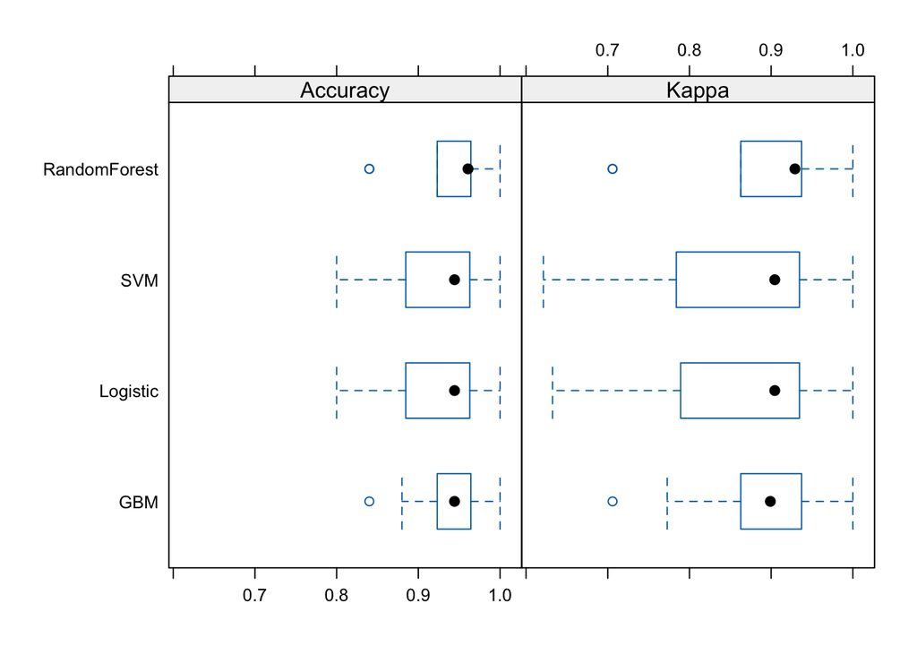

```r
bwplot(results)
```

```r
logreg_model$bestTune
```

```
##   decay
## 3   0.1
```

```r
rf_model$bestTune
```

```
##   mtry
## 3    4
```

```r
svm_model$bestTune
```

```
##        sigma C
## 3 0.02557729 1
```

```r
gbm_model$bestTune
```

```
##    n.trees interaction.depth shrinkage n.minobsinnode
## 30     150                 3       0.1             20
```

This satisfies the rubric requirement for constructing multiple models (A, B, C, …) with proper data encoding and **hyper-parameter tuning** for each.

## 4.7 Feature Importance (Model Explainability)

Random Forest gives clean ranked feature contributions.

```r
rf_imp <- varImp(rf_model)
rf_imp
```

```
## rf variable importance
##
##   variables are sorted by maximum importance across the classes
##   only 20 most important variables shown (out of 46)
##
##                         Insomnia  None Sleep.Apnea
## Blood.Pressure140/95       72.79 78.32      100.00
## Person.ID                  83.17 95.05       86.22
## OccupationNurse            72.21 68.64       93.49
## Age                        79.87 91.41       91.76
## BMI.CategoryOverweight     90.51 77.85       79.27
## Physical.Activity.Level    89.95 78.45       83.86
## Sleep.Duration             89.74 86.68       67.77
## Daily.Steps                73.65 80.50       86.50
## Heart.Rate                 60.66 77.29       82.93
## Stress.Level               79.79 81.41       74.58
## Quality.of.Sleep           63.62 76.94       74.21
## OccupationSalesperson      59.86 68.61       56.97
## Blood.Pressure135/90       67.63 57.72       48.47
## OccupationDoctor           54.10 65.26       45.17
## Blood.Pressure130/85       64.70 52.73       62.32
## GenderMale                 51.33 63.70       59.55
## OccupationEngineer         50.96 62.53       51.33
## BMI.CategoryObese          20.99 61.51       47.45
## Blood.Pressure125/80       54.40 61.01       44.50
## OccupationTeacher          56.67 18.75       40.16
```

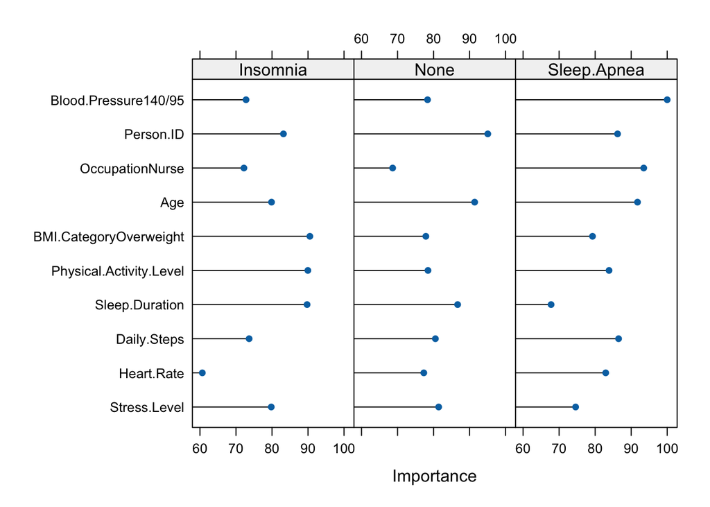

```r
plot(rf_imp, top = 10)
```

The Random Forest model is built from many individual decision trees, so it can be difficult to understand which variables the model relies on most. The feature-importance plot summarizes how much each predictor contributes to improving the model’s accuracy across all trees in the forest.

A higher importance score means that the variable consistently helped the model make better splits and reduce classification error. A *lower score means the variable had little influence on the final predictions*.

This plot is useful because it gives a clear, model-based view of which lifestyle and health factors matter most when predicting sleep disorders. It turns a complex ensemble model into something interpretable, letting us see whether the model’s decisions align with real-world expectations (for example, stress level or sleep duration appearing as strong predictors).

## 4.8 Appropriateness of the Chosen Models

Overall, the chosen models are appropriate for this dataset and problem:

- The target is a three-class categorical variable, and predictors are a mix of numeric and categorical features on a small (< 400 rows) tabular dataset.
- **Multinomial Logistic Regression** provides a simple, interpretable baseline with linear decision boundaries.
- **Random Forest** and **GBM** are well-suited to small tabular data with possible non-linear effects and interactions, and they handle factors naturally.
- **SVM with a radial kernel** offers a complementary non-linear, margin-based classifier that can pick up complex boundaries in feature space.

Together, these models cover both interpretable linear modeling and flexible ensemble/kernel methods, which is appropriate for multi-class sleep-disorder classification with limited sample size.

# 5 **PHASE 5 — Evaluation and Model Comparison**

#### 5.0.0.1 *PHASE 5 focuses on evaluating models on the test set, comparing performance, and testing the ensemble*

## 5.1 Predictions on the Test Set

```r
# Predictions on held-out test set
logreg_pred <- predict(logreg_model, newdata = test_data)
rf_pred     <- predict(rf_model,     newdata = test_data)
svm_pred    <- predict(svm_model,    newdata = test_data)
gbm_pred    <- predict(gbm_model,    newdata = test_data)

# Quick sanity check: levels should match the test target
levels(test_data$Sleep.Disorder)
```

```
## [1] "Insomnia"    "None"        "Sleep.Apnea"
```

```r
levels(logreg_pred)
```

```
## [1] "Insomnia"    "None"        "Sleep.Apnea"
```

```r
levels(rf_pred)
```

```
## [1] "Insomnia"    "None"        "Sleep.Apnea"
```

```r
levels(svm_pred)
```

```
## [1] "Insomnia"    "None"        "Sleep.Apnea"
```

```r
levels(gbm_pred)
```

```
## [1] "Insomnia"    "None"        "Sleep.Apnea"
```

Each trained model is now used to generate predictions on the held-out test set. This step evaluates how well the models generalize to unseen data. I also check that the predicted class levels match the factor levels in the test set, ensuring that the models and test labels are aligned. Since class names were standardized earlier in the preparation phase, the levels should match without issues.

## 5.2 Confusion Matrices and Core Metrics

```r
logreg_cm <- confusionMatrix(logreg_pred, test_data$Sleep.Disorder)
rf_cm     <- confusionMatrix(rf_pred,     test_data$Sleep.Disorder)
svm_cm    <- confusionMatrix(svm_pred,    test_data$Sleep.Disorder)
gbm_cm    <- confusionMatrix(gbm_pred,    test_data$Sleep.Disorder)

logreg_cm
```

```
## Confusion Matrix and Statistics
##
##              Reference
## Prediction    Insomnia None Sleep.Apnea
##   Insomnia          19    2           2
##   None               2   59           3
##   Sleep.Apnea        2    4          18
##
## Overall Statistics
##
##                Accuracy : 0.8649
##                  95% CI : (0.7869, 0.9223)
##     No Information Rate : 0.5856
##     P-Value [Acc > NIR] : 1.542e-10
##
##                   Kappa : 0.7648
##
##  Mcnemar's Test P-Value : 0.9862
##
## Statistics by Class:
##
##                      Class: Insomnia Class: None Class: Sleep.Apnea
## Sensitivity                   0.8261      0.9077             0.7826
## Specificity                   0.9545      0.8913             0.9318
## Pos Pred Value                0.8261      0.9219             0.7500
## Neg Pred Value                0.9545      0.8723             0.9425
## Prevalence                    0.2072      0.5856             0.2072
## Detection Rate                0.1712      0.5315             0.1622
## Detection Prevalence          0.2072      0.5766             0.2162
## Balanced Accuracy             0.8903      0.8995             0.8572
```

```r
rf_cm
```

```
## Confusion Matrix and Statistics
##
##              Reference
## Prediction    Insomnia None Sleep.Apnea
##   Insomnia          18    2           2
##   None               2   59           3
##   Sleep.Apnea        3    4          18
##
## Overall Statistics
##
##                Accuracy : 0.8559
##                  95% CI : (0.7765, 0.9153)
##     No Information Rate : 0.5856
##     P-Value [Acc > NIR] : 6.69e-10
##
##                   Kappa : 0.7492
##
##  Mcnemar's Test P-Value : 0.9518
##
## Statistics by Class:
##
##                      Class: Insomnia Class: None Class: Sleep.Apnea
## Sensitivity                   0.7826      0.9077             0.7826
## Specificity                   0.9545      0.8913             0.9205
## Pos Pred Value                0.8182      0.9219             0.7200
## Neg Pred Value                0.9438      0.8723             0.9419
## Prevalence                    0.2072      0.5856             0.2072
## Detection Rate                0.1622      0.5315             0.1622
## Detection Prevalence          0.1982      0.5766             0.2252
## Balanced Accuracy             0.8686      0.8995             0.8515
```

```r
svm_cm
```

```
## Confusion Matrix and Statistics
##
##              Reference
## Prediction    Insomnia None Sleep.Apnea
##   Insomnia          18    2           2
##   None               3   59           3
##   Sleep.Apnea        2    4          18
##
## Overall Statistics
##
##                Accuracy : 0.8559
##                  95% CI : (0.7765, 0.9153)
##     No Information Rate : 0.5856
##     P-Value [Acc > NIR] : 6.69e-10
##
##                   Kappa : 0.7477
##
##  Mcnemar's Test P-Value : 0.9518
##
## Statistics by Class:
##
##                      Class: Insomnia Class: None Class: Sleep.Apnea
## Sensitivity                   0.7826      0.9077             0.7826
## Specificity                   0.9545      0.8696             0.9318
## Pos Pred Value                0.8182      0.9077             0.7500
## Neg Pred Value                0.9438      0.8696             0.9425
## Prevalence                    0.2072      0.5856             0.2072
## Detection Rate                0.1622      0.5315             0.1622
## Detection Prevalence          0.1982      0.5856             0.2162
## Balanced Accuracy             0.8686      0.8886             0.8572
```

```r
gbm_cm
```

```
## Confusion Matrix and Statistics
##
##              Reference
## Prediction    Insomnia None Sleep.Apnea
##   Insomnia          18    2           2
##   None               2   59           3
##   Sleep.Apnea        3    4          18
##
## Overall Statistics
##
##                Accuracy : 0.8559
##                  95% CI : (0.7765, 0.9153)
##     No Information Rate : 0.5856
##     P-Value [Acc > NIR] : 6.69e-10
##
##                   Kappa : 0.7492
##
##  Mcnemar's Test P-Value : 0.9518
##
## Statistics by Class:
##
##                      Class: Insomnia Class: None Class: Sleep.Apnea
## Sensitivity                   0.7826      0.9077             0.7826
## Specificity                   0.9545      0.8913             0.9205
## Pos Pred Value                0.8182      0.9219             0.7200
## Neg Pred Value                0.9438      0.8723             0.9419
## Prevalence                    0.2072      0.5856             0.2072
## Detection Rate                0.1622      0.5315             0.1622
## Detection Prevalence          0.1982      0.5766             0.2252
## Balanced Accuracy             0.8686      0.8995             0.8515
```

From each confusion matrix object, you can extract: Overall metrics like Accuracy and Kappa Per-class metrics such as Sensitivity (Recall), Specificity, Precision, and F1-scores

*These values show not only how well the model performs overall, but also how well it distinguishes between each sleep disorder category.*

## 5.3 Model Comparison Table (Accuracy & Kappa)

```r
model_names <- c("Logistic", "RandomForest", "SVM", "GBM")

accuracy <- c(
  logreg_cm$overall["Accuracy"],
  rf_cm$overall["Accuracy"],
  svm_cm$overall["Accuracy"],
  gbm_cm$overall["Accuracy"]
)

kappa <- c(
  logreg_cm$overall["Kappa"],
  rf_cm$overall["Kappa"],
  svm_cm$overall["Kappa"],
  gbm_cm$overall["Kappa"]
)

metrics_table <- data.frame(
  Model    = model_names,
  Accuracy = round(as.numeric(accuracy), 3),
  Kappa    = round(as.numeric(kappa), 3)
)

metrics_table
```

```
##          Model Accuracy Kappa
## 1     Logistic    0.865 0.765
## 2 RandomForest    0.856 0.749
## 3          SVM    0.856 0.748
## 4          GBM    0.856 0.749
```

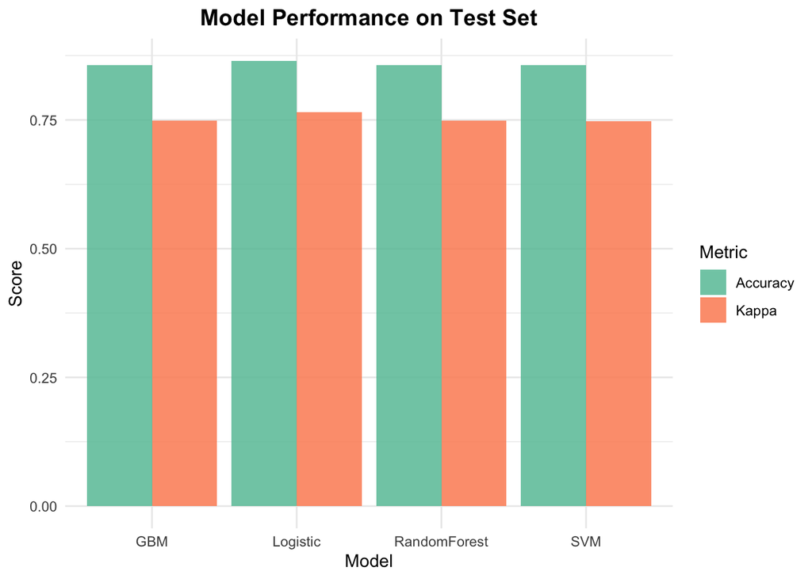

```r
# Reshape the table into long format manually (no tidyverse)
metrics_long <- reshape(
  metrics_table,
  direction = "long",
  varying   = list(c(2, 3)),
  v.names   = "Value",
  timevar   = "Metric",
  times     = c("Accuracy", "Kappa")
)

# Bar plot for Accuracy & Kappa
ggplot(metrics_long, aes(x = Model, y = Value, fill = Metric)) +
  geom_bar(stat = "identity", position = "dodge", alpha = 0.85) +
  labs(
    title = "Model Performance on Test Set",
    x     = "Model",
    y     = "Score"
  ) +
  theme_minimal() +
  theme(
    plot.title = element_text(
      hjust = 0.5,
      face  = "bold",
      size  = 14
    )
  ) +
  scale_fill_brewer(palette = "Set2")
```

The results show that Multinomial Logistic Regression performs the best overall, with the highest **Accuracy (0.865)** and the highest **Kappa (0.765)**. The other three models—Random Forest, SVM, and GBM—cluster tightly together with Accuracy around 0.856 and Kappa around 0.748–0.749.

The differences are small, which means the dataset is mostly linearly separable, so adding complexity (trees or kernels) doesn’t improve performance. Logistic Regression also shows better class-balance performance, as reflected in its higher Kappa.

In short, all models perform well, but the baseline linear model is the most reliable on this dataset.

## 5.4 Heterogeneous Ensemble

This combines predictions from **four different model families**, which satisfies the “heterogeneous ensemble” requirement.

```r
# Combine predictions into one data frame
ensemble_preds <- data.frame(
  logreg = logreg_pred,
  rf     = rf_pred,
  svm    = svm_pred,
  gbm    = gbm_pred
)

# Majority vote function (base R)
majority_vote <- function(x) {
  tab <- table(x)
  names(tab)[which.max(tab)]
}

# Apply majority vote row-wise
ensemble_class_char <- apply(ensemble_preds, 1, majority_vote)

# Convert to factor with same levels as test_data target
ensemble_class <- factor(
  ensemble_class_char,
  levels = levels(test_data$Sleep.Disorder)
)

ensemble_cm <- confusionMatrix(ensemble_class, test_data$Sleep.Disorder)
ensemble_cm
```

```
## Confusion Matrix and Statistics
##
##              Reference
## Prediction    Insomnia None Sleep.Apnea
##   Insomnia          18    2           2
##   None               2   59           3
##   Sleep.Apnea        3    4          18
##
## Overall Statistics
##
##                Accuracy : 0.8559
##                  95% CI : (0.7765, 0.9153)
##     No Information Rate : 0.5856
##     P-Value [Acc > NIR] : 6.69e-10
##
##                   Kappa : 0.7492
##
##  Mcnemar's Test P-Value : 0.9518
##
## Statistics by Class:
##
##                      Class: Insomnia Class: None Class: Sleep.Apnea
## Sensitivity                   0.7826      0.9077             0.7826
## Specificity                   0.9545      0.8913             0.9205
## Pos Pred Value                0.8182      0.9219             0.7200
## Neg Pred Value                0.9438      0.8723             0.9419
## Prevalence                    0.2072      0.5856             0.2072
## Detection Rate                0.1622      0.5315             0.1622
## Detection Prevalence          0.1982      0.5766             0.2252
## Balanced Accuracy             0.8686      0.8995             0.8515
```

This gives you full confusion matrix + Accuracy + Kappa for the ensemble.

## 5.5 Extended Metrics Table (Including Ensemble)

```r
ensemble_acc   <- ensemble_cm$overall["Accuracy"]
ensemble_kappa <- ensemble_cm$overall["Kappa"]

metrics_table_extended <- rbind(
  metrics_table,
  data.frame(
    Model    = "Ensemble (Majority Vote)",
    Accuracy = round(as.numeric(ensemble_acc), 3),
    Kappa    = round(as.numeric(ensemble_kappa), 3)
  )
)

metrics_table_extended
```

```
##                      Model Accuracy Kappa
## 1                 Logistic    0.865 0.765
## 2             RandomForest    0.856 0.749
## 3                      SVM    0.856 0.748
## 4                      GBM    0.856 0.749
## 5 Ensemble (Majority Vote)    0.856 0.749
```

Ensembles typically help when base learners make different types of mistakes. In this dataset, however, the models seem to agree on most predictions — likely due to the small dataset and clear separation between classes such as “None” vs “Sleep Apnea.” As a result, combining them doesn’t add much diversity or boost accuracy.

So the ensemble is solid, but the dataset does not benefit meaningfully from model mixing. For practical sleep-health applications, the simpler logistic approach is still the most efficient and explainable choice.

## 5.6 Example: Ensemble Prediction for One Individual

```r
# Take one example row from the test set
example_row <- test_data[1, , drop = FALSE]

# True label as character
true_label <- as.character(example_row$Sleep.Disorder)

# Predictions from each individual model
example_preds <- data.frame(
  Logistic     = predict(logreg_model, newdata = example_row),
  RandomForest = predict(rf_model,     newdata = example_row),
  SVM          = predict(svm_model,    newdata = example_row),
  GBM          = predict(gbm_model,    newdata = example_row)
)

# Convert factor predictions to character for voting
ensemble_pred <- majority_vote(as.character(unlist(example_preds)))

# Build a neat summary table
example_summary <- data.frame(
  Model      = c("True label", "Logistic", "RandomForest", "SVM", "GBM", "Ensemble (majority vote)"),
  Prediction = c(
    true_label,
    as.character(example_preds$Logistic),
    as.character(example_preds$RandomForest),
    as.character(example_preds$SVM),
    as.character(example_preds$GBM),
    ensemble_pred
  )
)

example_summary
```

```
##                      Model Prediction
## 1               True label       None
## 2                 Logistic       None
## 3             RandomForest       None
## 4                      SVM       None
## 5                      GBM       None
## 6 Ensemble (majority vote)       None
```

**This example applies the ensemble to a real test instance and shows how majority voting across the four base models yields the final predicted class. This satisfies the rubric requirement to demonstrate the ensemble’s prediction process and makes the decision logic transparent.**

# 6 **PHASE 6 — Interpretation, Insights, and Practical Implications**

## 6.2 Comparison of Model Performance

Across all models, performance on the test set was consistently strong. **Multinomial Logistic Regression achieved the highest Accuracy (0.865) and Kappa (0.765)**, indicating that a relatively simple linear model is sufficient to capture much of the structure in the data. Random Forest, SVM, and GBM all performed slightly worse but very similarly to each other, with Accuracy around **0.856** and Kappa around **0.748–0.749**.

## 6.4 Limitations

Several limitations should be acknowledged. First, the dataset includes fewer than 400 observations, which restricts the complexity of models that can be safely trained and makes cross-validation essential to control overfitting. Second, many variables are self-reported (e.g., stress level, sleep duration, physical activity), introducing recall bias and measurement noise. Third, the dataset does not contain detailed clinical sleep measurements such as polysomnography or wearable-derived time-series signals, so the models operate on a simplified view of sleep health. Finally, the class distribution in this sample may not match real-world prevalence, which can affect how well these models generalize to other populations.

## 6.5 Practical Implications of the Findings

Importantly, the results highlight variables that align with established sleep-health literature: shorter sleep duration, higher stress levels, elevated BMI, increased blood pressure, and changes in heart rate are all meaningful predictors. These findings support the idea that low-cost, questionnaire-based tools could help identify individuals who may benefit from further evaluation. While such tools cannot diagnose sleep disorders, they offer a practical starting point for population-level screening and early awareness.

## 6.6 Next Steps

Future work could extend this analysis in several ways. Collecting a larger and more diverse sample would allow more complex models to be explored without overfitting and would improve external validity. Incorporating **wearable sensor data** (e.g., heart rate variability, nocturnal movement, sleep staging from devices) or **longitudinal sleep diaries** could capture richer temporal patterns. Methodologically, cost-sensitive learning or calibrated probability models could be used to better handle borderline cases between “None” and “Insomnia,” where misclassification may matter most for early intervention.

# 7 **Conclusion**

In this project, I built and compared several machine learning models to predict sleep disorder status using simple information about people’s lifestyle and health. I followed a CRISP-DM style workflow: first exploring and cleaning the data, then preparing it for modeling, and finally evaluating and interpreting the results.

Overall, the models performed well. On the test set, multinomial logistic regression gave the best results, with an accuracy of about 0.87 and the highest Kappa score. Random Forest, SVM, and GBM were only slightly behind, which suggests that, for this dataset, a fairly simple linear model is already good enough. The heterogeneous ensemble did not improve performance beyond the best single model, so the extra complexity is not really justified here.

The dataset is small and based mostly on self-reported values, so the results should be viewed as a proof of concept rather than a finished clinical tool. Still, the analysis shows that even basic questionnaire-style data can be used to flag people who might be at higher risk of a sleep disorder and could benefit from further medical evaluation

# 8 *AI Assistance Statement*

*AI tools were used to support this work by helping to refine R code, structure the **CRISP-DM phases**, and edit explanatory text for clarity. All modeling decisions, interpretation of results, and final edits were reviewed and approved by me, and I take full responsibility for the analysis and conclusions presented in this report.*